# output

xj2249

12/15/2019

# Data cleaning

```r
# import
df = read_csv("Lawsuit.csv") %>%
  janitor::clean_names() %>%
  mutate(dept = factor(dept, levels = c(1:6), labels = c("Biochemistry/Molecular Biology", "Physiology ", "Genetics", "Pediatrics", "Medicine", "Surgery")),
         gender = factor(gender, levels = c(0, 1), labels = c("Female","Male")),
         clin = factor(clin, levels = c(1, 0), labels = c("Clinical","Research")),
         cert = factor(cert, levels = c(1, 0), labels = c("Certified","Not certified")),
         rank = factor(rank, levels = c(1, 2, 3), labels = c("Assistant", "Associate", "Full professor")),
         sal = (sal94 + sal95)/2)
# consider log mean sal only
df_sal = df %>%
  mutate(log_sal = log(sal)) %>%
  dplyr::select(-sal95, -id, -sal94, -sal)
```

## interaction term (not sure whether to test)

```r
## general test

# no prate
fit_conf = lm(log_sal ~gender+dept+clin+cert+exper+rank, data = df_sal)
summary(fit_conf)
```

Call: lm(formula = log_sal ~ gender + dept + clin + cert + exper + rank, data = df_sal)

Residuals: Min 1Q Median 3Q Max -0.34605 -0.07696 -0.01873 0.07596 0.90393

Coefficients: Estimate Std. Error t value Pr(>|t|)  
(Intercept) 11.373862 0.034398 330.651 < 2e-16 genderMale 0.025763 0.019624 1.313 0.19  
deptPhysiology -0.175749 0.029122 -6.035 5.73e-09 deptGenetics 0.185970 0.036501 5.095 6.90e-07 *deptPediatrics 0.203345 0.035712 5.694 3.48e-08* deptMedicine 0.539304 0.029515 18.272 < 2e-16 *deptSurgery 0.933820 0.035533 26.280 < 2e-16* clinResearch -0.208340 0.021885 -9.520 < 2e-16 *certNot certified -0.189749 0.021244 -8.932 < 2e-16* exper 0.017726 0.001812 9.783 < 2e-16 *rankAssociate 0.134663 0.023557 5.716 3.10e-08* rankFull professor 0.222214 0.026249 8.466 2.22e-15 *** — Signif. codes: 0 ‘**’ 0.001 ’**’ 0.01 ’’ 0.05 ‘.’ 0.1 ’ ’ 1

Residual standard error: 0.1337 on 249 degrees of freedom Multiple R-squared: 0.9339, Adjusted R-squared: 0.931 F-statistic: 319.7 on 11 and 249 DF, p-value: < 2.2e-16

```r
fit_int = lm(log_sal ~gender+dept+clin+cert+exper+rank+gender*exper, data = df_sal)
```

Interaction term $gender*exper$ is significant, thus we may conside it in our model.

## stratified regression

```r
stratified_dept = df_sal %>%
  group_by(dept) %>%
  summarize(
      n = n(),
      coef =  lm(log_sal ~ gender+clin+cert+exper+rank)$coef["genderMale"],
      p = summary(lm(log_sal ~ gender+clin+cert+exper+rank))$coefficients["genderMale",4]
            )
stratified_dept %>%
    knitr::kable()
```

| dept | n | coef | p |
| --- | --- | --- | --- |
| Biochemistry/Molecular Biology | 50 | -0.0187106 | 0.6600235 |
| Physiology | 40 | -0.0052950 | 0.9224663 |
| Genetics | 21 | 0.0754572 | 0.2339215 |
| Pediatrics | 30 | 0.0115277 | 0.8453661 |
| Medicine | 80 | 0.0366927 | 0.3660339 |
| Surgery | 40 | 0.0416427 | 0.4947262 |

```r
stratified_clin = df_sal %>%
  group_by(clin) %>%
  summarize(
      n = n(),
      coef =  lm(log_sal ~ gender + dept + cert + exper +
    rank)$coef["genderMale"],
      p = summary(lm(log_sal ~ gender + dept + cert + exper +
    rank))$coefficients["genderMale",4]
            )
stratified_clin %>%
    knitr::kable()
```

| clin | n | coef | p |
| --- | --- | --- | --- |
| Clinical | 160 | 0.0083165 | 0.7108663 |
| Research | 101 | 0.0465115 | 0.2948187 |

```r
stratified_cert = df_sal %>%
  group_by(cert) %>%
  summarize(
      n = n(),
      coef =  lm(log_sal ~ gender + dept + clin + exper +
    rank)$coef["genderMale"],
      p = summary(lm(log_sal ~ gender + dept + clin + exper +
    rank))$coefficients["genderMale",4]
            )
stratified_cert %>%
    knitr::kable()
```

| cert | n | coef | p |
| --- | --- | --- | --- |
| Certified | 188 | 0.0126811 | 0.5584154 |
| Not certified | 73 | 0.0265111 | 0.5547041 |

```r
stratified_rank = df_sal %>%
  group_by(rank) %>%
  summarize(
      n = n(),
      coef =  lm(log_sal ~ gender + dept + clin + cert + exper)$coef["genderMale"],
      p = summary(lm(log_sal ~ gender + dept + clin + cert + exper))$coefficients["genderMale",4]
            )
stratified_rank %>%
    knitr::kable()
```

| rank | n | coef | p |
| --- | --- | --- | --- |
| Assistant | 112 | 0.0826555 | 0.0213160 |
| Associate | 64 | -0.0132771 | 0.6702516 |
| Full professor | 85 | -0.0404129 | 0.2680458 |

```r
df_exper = df_sal %>%
  mutate(exper_fct = case_when(
      exper < 6 ~ "0",
      exper >= 6 & exper < 9 ~ "1",
      exper >= 9 & exper < 14 ~ "2",
      exper >= 14 ~ "3",
      TRUE ~ ""
  )) %>%
    mutate(exper = factor(exper_fct)) %>%
    dplyr::select(-exper_fct)

stratified_exper = df_exper %>%
  group_by(exper) %>%
  summarize(
      n = n(),
      coef =  lm(log_sal ~ gender + dept + clin + cert + rank)$coef["genderMale"],
      p = summary(lm(log_sal ~ gender + dept + clin + cert + rank))$coefficients["genderMale",4]
            )
stratified_exper %>%
    knitr::kable()
```

| exper | n | coef | p |
| --- | --- | --- | --- |
| 0 | 64 | 0.1257741 | 0.0238410 |
| 1 | 57 | 0.0340942 | 0.2757676 |
| 2 | 74 | -0.0005508 | 0.9876466 |
| 3 | 66 | -0.0034961 | 0.9439975 |

```r
df_exper  %>%
  group_by(exper, rank) %>%
  summarize(
      n = n())
```

```
## # A tibble: 11 x 3
## # Groups:   exper [4]
##    exper rank               n
##    <fct> <fct>          <int>
##  1 0     Assistant         59
##  2 0     Associate          5
##  3 1     Assistant         36
##  4 1     Associate         15
##  5 1     Full professor     6
##  6 2     Assistant         12
##  7 2     Associate         31
##  8 2     Full professor    31
##  9 3     Assistant          5
## 10 3     Associate         13
## 11 3     Full professor    48
```

# Model diagnostics

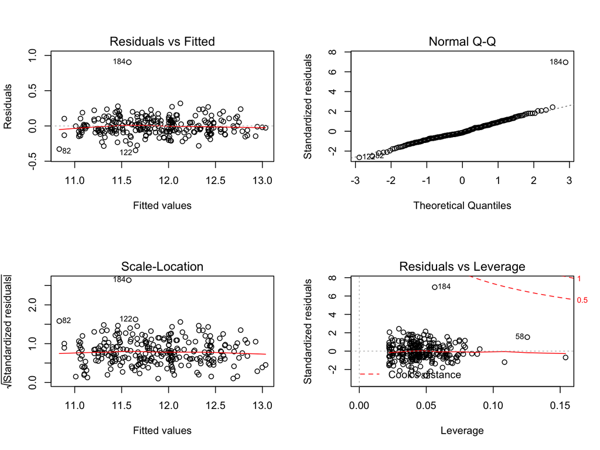

```r
final_model = lm(log_sal ~gender+dept+clin+cert+exper+rank, data = df_sal)
par(mfrow = c(2,2))
plot(final_model)
```

# Outliers/influential points

```r
stu_res<-rstandard(final_model)
stu_res[abs(stu_res)>2.5]
```

```
##        82       122       184
## -2.507753 -2.640742  6.960085
```

```r
influence.measures(final_model) %>%
  summary()
```

```
## Potentially influential observations of
##   lm(formula = log_sal ~ gender + dept + clin + cert + exper +      rank, data = df_sal) :
##
##     dfb.1_ dfb.gndM dfb.dptPh dfb.dptG dfb.dptPd dfb.dptM dfb.dptS
## 19   0.08  -0.01     0.04      0.04     0.00      0.03     0.03
## 82   0.01   0.07    -0.31      0.00    -0.05     -0.08    -0.11
## 91   0.04  -0.01    -0.01     -0.08    -0.02     -0.02    -0.01
## 109  0.00  -0.02     0.00      0.05     0.00      0.01     0.01
## 122 -0.14   0.07     0.03      0.04    -0.27      0.08     0.06
## 184 -0.62   0.75     0.22      0.16     0.53      1.00     0.53
## 208  0.06  -0.19    -0.01     -0.01    -0.04      0.11    -0.02
##     dfb.clnR dfb.crNc dfb.expr dfb.rnkA dfb.rnFp dffit   cov.r   cook.d
## 19  -0.01    -0.09    -0.26     0.05     0.17    -0.30    1.21_*  0.01
## 82  -0.13    -0.18     0.08     0.12     0.07    -0.54    0.81_*  0.02
## 91  -0.04     0.03    -0.04     0.02     0.01    -0.10    1.15_*  0.00
## 109  0.02    -0.03     0.00     0.03     0.00     0.07    1.15_*  0.00
## 122  0.11     0.02     0.02     0.10     0.05    -0.54    0.78_*  0.02
## 184  0.94     0.84    -0.36    -0.51    -0.26     1.89_*  0.08_*  0.24
## 208 -0.06    -0.04     0.21    -0.14    -0.18     0.43    0.81_*  0.02
##     hat
## 19   0.15_*
## 82   0.04
## 91   0.09
## 109  0.09
## 122  0.04
## 184  0.06
## 208  0.03
```

```r
df[184,]
```

```
## # A tibble: 1 x 11
##      id dept   gender clin   cert    prate exper rank   sal94  sal95    sal
##   <dbl> <fct>  <fct>  <fct>  <fct>   <dbl> <dbl> <fct>  <dbl>  <dbl>  <dbl>
## 1   184 Medic… Male   Resea… Not ce…   5.1     2 Assi… 250000 276163 2.63e5
```

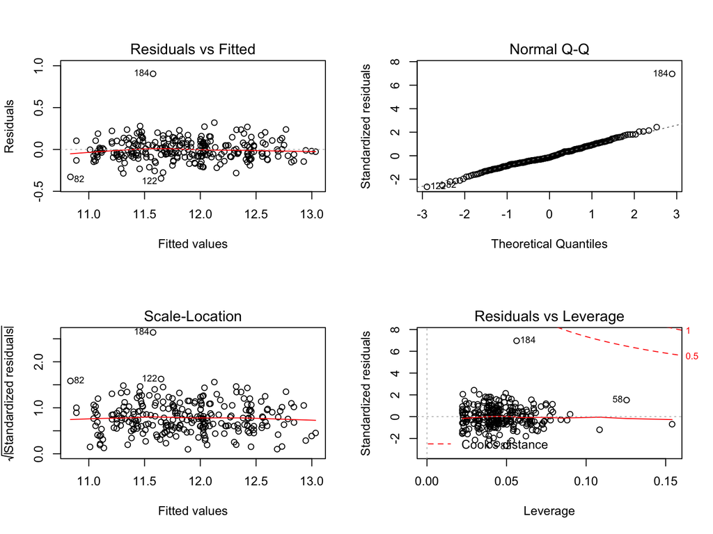

```r
# consider the data without influential points
df_sal_noinflu = df_sal[-184, ]

par(mfrow = c(2,2))
plot(final_model)
```

```r
temp = lm(log_sal ~gender+dept+clin+cert+exper+gender*rank+gender*exper, data = df_sal_noinflu)
summary(temp)
```

Call: lm(formula = log_sal ~ gender + dept + clin + cert + exper + gender * rank + gender * exper, data = df_sal_noinflu)

Residuals: Min 1Q Median 3Q Max -0.32895 -0.07173 -0.01277 0.08089 0.28179

Coefficients: Estimate Std. Error t value Pr(>|t|)  
(Intercept) 11.324438 0.039263 288.429 < 2e-16 **genderMale 0.100527 0.034725 2.895 0.00413** deptPhysiology -0.172382 0.026182 -6.584 2.77e-10 **deptGenetics 0.183611 0.032499 5.650 4.45e-08** *deptPediatrics 0.200148 0.032276 6.201 2.36e-09* **deptMedicine 0.520522 0.026654 19.529 < 2e-16** *deptSurgery 0.922849 0.031852 28.973 < 2e-16* **clinResearch -0.225913 0.020356 -11.098 < 2e-16** *certNot certified -0.198053 0.019681 -10.063 < 2e-16* **exper 0.026606 0.003887 6.845 6.11e-11** *rankAssociate 0.138212 0.033015 4.186 3.95e-05* **rankFull professor 0.213618 0.044342 4.817 2.55e-06** genderMale:rankAssociate -0.011198 0.043888 -0.255 0.79882  
genderMale:rankFull professor 0.002157 0.054723 0.039 0.96858  
genderMale:exper -0.009676 0.004265 -2.269 0.02416  
— Signif. codes: 0 ‘**’ 0.001 ’**’ 0.01 ’’ 0.05 ‘.’ 0.1 ’ ’ 1

Residual standard error: 0.1188 on 245 degrees of freedom Multiple R-squared: 0.9483, Adjusted R-squared: 0.9454 F-statistic: 321.2 on 14 and 245 DF, p-value: < 2.2e-16

```r
stargazer(fit_int,temp,type = "html",
          dep.var.labels = c("Log Salary"),
          covariate.labels = c("Male","Physiology","Genetics","Pediatrics","Medicine", "Surgery",
                             "Research emphasis","Not board certified","Experience","Associate",
                             "Full professor","Male:Experience","Male:Associate","Male:Full professor"),
          column.labels   = c("Final model", "Final model without 184")
          )
```

|  | *Dependent variable:* |  |
| --- | --- | --- |
|  | Log Salary |  |
|  | Final model | Final model without 184 |
|  | (1) | (2) |
| Male | 0.129*** | 0.101*** |
|  | (0.037) | (0.035) |
| Physiology | -0.165*** | -0.172*** |
|  | (0.029) | (0.026) |
| Genetics | 0.190*** | 0.184*** |
|  | (0.036) | (0.032) |
| Pediatrics | 0.219*** | 0.200*** |
|  | (0.035) | (0.032) |
| Medicine | 0.547*** | 0.521*** |
|  | (0.029) | (0.027) |
| Surgery | 0.940*** | 0.923*** |
|  | (0.035) | (0.032) |
| Research emphasis | -0.208*** | -0.226*** |
|  | (0.021) | (0.020) |
| Not board certified | -0.182*** | -0.198*** |
|  | (0.021) | (0.020) |
| Experience | 0.028*** | 0.027*** |
|  | (0.004) | (0.004) |
| Associate | 0.118*** | 0.138*** |
|  | (0.024) | (0.033) |
| Full professor | 0.208*** | 0.214*** |
|  | (0.026) | (0.044) |
| Male:Experience |  | -0.011 |
|  |  | (0.044) |
| Male:Associate |  | 0.002 |
|  |  | (0.055) |
| Male:Full professor | -0.012*** | -0.010** |
|  | (0.004) | (0.004) |
| Constant | 11.294*** | 11.324*** |
|  | (0.042) | (0.039) |
| Observations | 261 | 260 |
| R<sup>2</sup> | 0.937 | 0.948 |
| Adjusted R<sup>2</sup> | 0.934 | 0.945 |
| Residual Std. Error | 0.131 (df = 248) | 0.119 (df = 245) |
| F Statistic | 305.449*** (df = 12; 248) | 321.180*** (df = 14; 245) |
| *Note:* | p<0.1; p<0.05; p<0.01 |  |

```r
df_exper_noinflu = df_sal_noinflu %>%
  mutate(exper_fct = case_when(
      exper < 6 ~ "0",
      exper >= 6 & exper < 9 ~ "1",
      exper >= 9 & exper < 14 ~ "2",
      exper >= 14 ~ "3",
      TRUE ~ ""
  )) %>%
    mutate(exper = factor(exper_fct)) %>%
    dplyr::select(-exper_fct)

stratified_exper_noinflu = df_exper_noinflu %>%
  group_by(exper) %>%
  summarize(
      n = n(),
      coef =  lm(log_sal ~ gender + dept + clin + cert + rank)$coef["genderMale"],
      p = summary(lm(log_sal ~ gender + dept + clin + cert + rank))$coefficients["genderMale",4]
            )
stratified_exper_noinflu %>%
    knitr::kable()
```

| exper | n | coef | p |
| --- | --- | --- | --- |
| 0 | 63 | 0.0577437 | 0.2066119 |
| 1 | 57 | 0.0340942 | 0.2757676 |
| 2 | 74 | -0.0005508 | 0.9876466 |
| 3 | 66 | -0.0034961 | 0.9439975 |

```r
stratified_rank_noinflu = df_sal_noinflu %>%
  group_by(rank) %>%
  summarize(
      n = n(),
      coef =  lm(log_sal ~ gender + dept + clin + cert + exper)$coef["genderMale"],
      p = summary(lm(log_sal ~ gender + dept + clin + cert + exper))$coefficients["genderMale",4]
            )
stratified_rank_noinflu %>%
    knitr::kable()
```

| rank | n | coef | p |
| --- | --- | --- | --- |
| Assistant | 111 | 0.0390298 | 0.2009195 |
| Associate | 64 | -0.0132771 | 0.6702516 |
| Full professor | 85 | -0.0404129 | 0.2680458 |

Not significant now, -184 usinf main effects model or -216, -184, -8 using interaction model.